# Exp4: 基于K-近邻的车牌号识别

## 一、案例简介

图像的智能处理一直是人工智能领域广受关注的一类技术，代表性的如人脸识别与 CT 肿瘤识别，在人工智能落地的进程中发挥着重要作用。其中车牌号识别作为一个早期应用场景，已经融入日常生活中，为我们提供了诸多便利，在各地的停车场和出入口都能看到它的身影。车牌号识别往往分为字符划分和字符识别两个子任务，本案例我们将关注字符识别的任务，尝试用 K-NN 的方法对分割好的字符图像进行自动识别和转化。

## 二、作业说明

### 基本要求

- 完成数据的读入和表示，将图片表示成向量并和 label 对应上；
- 构建 K-NN 模型（可调库）对测试集中的图片进行预测并计算准确率；
- 分析当 K 取不同值时测试准确率的变化。

### 扩展要求

- 分析不同距离度量方式对模型效果的影响；
- 对比平权和加权 K-NN 的效果；
- 分析训练集大小对测试结果的影响。

## 三、数据概览

本次我们使用已经分割好的车牌图片作为数据集，包括数字 0-9、字母 A-Z（不包含 O 和 I）以及省份简称共 65 个类，编号从 0 到 64。数据已经分成了训练集和测试集，里面的文件夹用 label 编号命名，一个文件夹下的所有图片都属于该文件夹对应的类，每个图片都是 20 * 20 的二值化灰度图。

下面演示一下如何借助 PIL 库将图片转化为向量：

```python
import pandas as pd
from PIL import Image
img = Image.open('data/train/0/4-3.jpg')  # 打开图片
img
```

[output not shown]

```python
import numpy as np
pixels = np.array(img)  # 转化为 numpy 矩阵
pixels.shape
```

```
(20, 20)
```

# 文件导入

```python
import os
from PIL import Image
from tqdm import tqdm
import numpy as np
import matplotlib.pyplot as plt
import pandas as pd
```

```python
def process_img(directory_path):
    """
    将目录中所有文件转化为size=20*20的numpy矩阵
    :param directory_path: 根目录的路径
    :return: 包含所有图片信息的列表
    """
    # 查找 根目录 下所有文件路径
    def find_all_files(directory_path):
        file_paths = []
        if os.path.isfile(directory_path):
            # 根目录是文件则直接返回该目录
            file_paths.append(directory_path)
            return file_paths
        else:
            # os.walk递归遍历根目录下所有文件
            for root, dirs, files in os.walk(directory_path):
                for file in files:
                    file_paths.append(os.path.join(root, file))
            file_paths_cleaned = [file_path for file_path in file_paths if not file_path.endswith('.DS_Store')]
            return file_paths_cleaned

    # 读取图片
    def extract_img(filepath):
        # 转化为 numpy 矩阵
        def to_array(img):
            pixels = np.array(img)
            return pixels.reshape(-1)
            return pixels

        img = Image.open(filepath)
        pixels = to_array(img)
        img.close()
        return pixels


    # 将根目录下每一个img文件转化为size=20*20 numpy矩阵
    pixels_list = []
    file_path = find_all_files(directory_path)
    for filepath in file_path:
        if os.path.isfile(filepath):
            pixels = extract_img(filepath)
            pixels_list.append(pixels)
    return pixels_list
```

# 加载训练集

```python
train_path = 'data/train/'
path = []
for i in range(65):
    path.append(train_path+str(i))

nums = []
train_pixels_list = []
# 分开加载，以便确认每个标签有多少图片
for i in path:
    result = process_img(i)
    nums.append(len(result))
    for i in result:
        train_pixels_list.append(i)
```

```python
X_train = train_pixels_list
```

```python
number = ['0','1','2','3','4','5','6','7','8','9']
alphabet = [chr(i) for i in range(65,91) if chr(i) not in ['I', 'O']]
district = ['皖','沪','津','渝','冀','晋','蒙','辽','吉','黑','苏','浙','京','闽','赣','鲁','豫','鄂','湘','粤','桂','琼','川','贵','云','藏','陕','甘','青','宁','新']
label = number+alphabet+district
# onehot_encoded = number+alphabet+district
len(label)
```

```
65
```

```python
from sklearn.preprocessing import OneHotEncoder
from sklearn.preprocessing import LabelEncoder
import numpy as np

# 将字符元素转换为唯一的整数标识符（Label Encoding）
label_encoder = LabelEncoder()
labels = label_encoder.fit_transform(label)
labels = np.array(labels).reshape(-1,1)


# # 创建 OneHotEncoder 对象并进行编码
# encoder = OneHotEncoder(sparse_output=False)
# onehot_encoded = encoder.fit_transform(labels)

# print("原始数据:")
# print(label)
# print("\n整数标签:")
# print(labels)
# print("\nOne-hot 编码结果:")
# print(onehot_encoded)
```

```python
y_train = []
for i in range(len(labels)):
    y_train.extend([labels[i]] * nums[i])
y_train = np.ravel(y_train) # np.ravel()函数，用于展平高维数组为1维数组
print(len(y_train))
```

```
15954
```

# 加载测试集

```python
test_path = 'data/test/'
path = []
for i in range(65):
    path.append(test_path+str(i))

nums = []
test_pixels_list = []
# 分开加载，以便确认每个标签有多少图片
for i in path:
    result = process_img(i)
    nums.append(len(result))
    for i in result:
        test_pixels_list.append(i)
```

```python
X_test = test_pixels_list
```

```python
y_test = []
for i in range(len(labels)):
    y_test.extend([labels[i]] * nums[i])
y_test = np.ravel(y_test)
print(len(y_test))
```

```
4665
```

```python
df = pd.DataFrame({'Feature':X_train, 'label':y_train})
df
```

|  | Feature | label |
| --- | --- | --- |
| 0 | [1, 0, 1, 0, 0, 2, 26, 139, 254, 255, 254, 254... | 0 |
| 1 | [0, 2, 0, 0, 5, 0, 0, 22, 247, 255, 255, 249, ... | 0 |
| 2 | [0, 3, 0, 0, 4, 0, 1, 58, 217, 255, 251, 217, ... | 0 |
| 3 | [3, 0, 0, 3, 3, 0, 2, 14, 187, 253, 255, 187, ... | 0 |
| 4 | [0, 0, 1, 0, 2, 1, 0, 15, 23, 26, 233, 25, 26,... | 0 |
| ... | ... | ... |
| 15949 | [1, 2, 3, 1, 0, 1, 8, 195, 48, 0, 1, 2, 0, 5, ... | 40 |
| 15950 | [2, 0, 4, 0, 2, 3, 0, 19, 240, 13, 0, 10, 46, ... | 40 |
| 15951 | [0, 2, 0, 6, 10, 146, 255, 254, 48, 13, 0, 50,... | 40 |
| 15952 | [0, 2, 0, 5, 5, 7, 169, 255, 35, 5, 3, 12, 11,... | 40 |
| 15953 | [0, 0, 3, 47, 248, 249, 255, 252, 251, 136, 2,... | 40 |

15954 rows × 2 columns

# 分割训练集

```python
from sklearn.model_selection import train_test_split
from sklearn.model_selection import cross_val_score
RANDOM_SEED = 2024

# 然后将训练集进一步划分为训练集和验证集
X_train, X_val, y_train, y_val  = train_test_split(X_train, y_train, test_size=0.1, random_state=RANDOM_SEED)
len(X_train), len(X_val), len(y_train), len(y_val)
```

```
(14358, 1596, 14358, 1596)
```

# 数据展示

```python
def flatten_feature(feature_data):
    return feature_data.values.flatten()
```

```python
train_data = {'Features': X_train, 'Labels': y_train}
train_df = pd.DataFrame(train_data)
train_df
```

|  | Features | Labels |
| --- | --- | --- |
| 0 | [1, 0, 0, 0, 6, 12, 169, 254, 255, 250, 255, 2... | 9 |
| 1 | [1, 0, 2, 2, 0, 0, 0, 33, 255, 255, 252, 71, 1... | 10 |
| 2 | [0, 0, 2, 0, 0, 0, 47, 132, 254, 255, 200, 84,... | 8 |
| 3 | [3, 0, 1, 1, 2, 28, 58, 0, 209, 185, 2, 8, 181... | 45 |
| 4 | [0, 4, 0, 0, 2, 0, 229, 255, 255, 253, 255, 95... | 7 |
| ... | ... | ... |
| 14353 | [3, 0, 4, 0, 0, 1, 255, 2, 0, 255, 252, 255, 2... | 60 |
| 14354 | [0, 0, 0, 0, 0, 0, 0, 0, 0, 3, 1, 34, 255, 255... | 4 |
| 14355 | [0, 0, 3, 0, 1, 0, 3, 0, 3, 0, 4, 26, 227, 24,... | 4 |
| 14356 | [3, 0, 3, 0, 62, 253, 251, 255, 251, 255, 255,... | 5 |
| 14357 | [0, 0, 1, 0, 2, 0, 0, 9, 154, 255, 220, 19, 0,... | 10 |

14358 rows × 2 columns

```python
val_data = {'Features': X_val, 'Labels': y_val}
val_df = pd.DataFrame(val_data)
val_df
```

|  | Features | Labels |
| --- | --- | --- |
| 0 | [0, 0, 1, 1, 1, 3, 0, 255, 254, 254, 107, 0, 0... | 10 |
| 1 | [0, 4, 0, 1, 26, 254, 255, 255, 254, 255, 255,... | 11 |
| 2 | [1, 0, 0, 6, 1, 1, 93, 255, 255, 232, 230, 255... | 24 |
| 3 | [0, 3, 1, 9, 178, 254, 255, 255, 254, 255, 255... | 3 |
| 4 | [0, 4, 0, 2, 14, 60, 255, 253, 251, 255, 255, ... | 8 |
| ... | ... | ... |
| 1591 | [1, 0, 1, 1, 1, 0, 255, 255, 255, 255, 253, 25... | 23 |
| 1592 | [1, 0, 4, 0, 14, 179, 50, 1, 4, 0, 255, 141, 0... | 43 |
| 1593 | [1, 3, 0, 2, 0, 4, 33, 36, 19, 0, 2, 2, 0, 2, ... | 44 |
| 1594 | [4, 0, 3, 2, 3, 0, 1, 96, 254, 141, 0, 2, 0, 1... | 37 |
| 1595 | [1, 0, 0, 3, 0, 0, 53, 254, 255, 253, 252, 220... | 25 |

1596 rows × 2 columns

```python
test_data = {'Features': X_test, 'Labels': y_test}
test_df = pd.DataFrame(test_data)
test_df
```

|  | Features | Labels |
| --- | --- | --- |
| 0 | [0, 0, 0, 0, 0, 0, 6, 30, 64, 80, 78, 75, 69, ... | 0 |
| 1 | [0, 2, 0, 2, 1, 1, 0, 2, 0, 0, 1, 0, 2, 2, 0, ... | 0 |
| 2 | [0, 0, 0, 0, 1, 1, 0, 2, 0, 1, 0, 2, 1, 0, 0, ... | 0 |
| 3 | [0, 1, 0, 1, 0, 1, 0, 0, 0, 0, 0, 1, 0, 0, 0, ... | 0 |
| 4 | [0, 0, 1, 0, 2, 0, 0, 1, 0, 1, 0, 0, 0, 2, 0, ... | 0 |
| ... | ... | ... |
| 4660 | [2, 0, 2, 2, 2, 6, 0, 2, 6, 114, 94, 0, 0, 0, ... | 38 |
| 4661 | [0, 3, 0, 4, 62, 252, 174, 8, 5, 0, 5, 6, 158,... | 40 |
| 4662 | [1, 0, 3, 2, 0, 143, 255, 61, 2, 0, 2, 13, 10,... | 40 |
| 4663 | [1, 4, 1, 0, 13, 13, 14, 3, 0, 0, 2, 10, 71, 1... | 40 |
| 4664 | [0, 1, 0, 1, 0, 0, 77, 255, 95, 2, 0, 9, 26, 2... | 40 |

4665 rows × 2 columns

# 数据预处理

```python
# 归一化
train_df['Features'] = train_df['Features'] / 255.0
val_df['Features'] = val_df['Features'] / 255.0
test_df['Features'] = test_df['Features'] / 255.0
```

# 训练k近邻模型

```
Accuracy for K=1: 0.7035369774919614
Accuracy for K=2: 0.6647374062165059
Accuracy for K=3: 0.692604501607717
Accuracy for K=4: 0.6784565916398714
Accuracy for K=5: 0.6866023579849947
Accuracy for K=6: 0.6812433011789925
Accuracy for K=7: 0.682529474812433
Accuracy for K=8: 0.6782422293676313
Accuracy for K=9: 0.6788853161843516
```

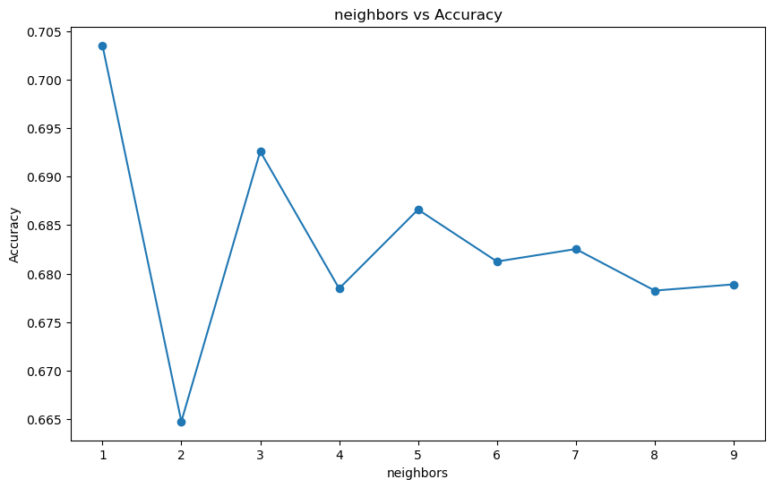

```python
from sklearn.neighbors import KNeighborsClassifier
from sklearn.metrics import accuracy_score, precision_score, recall_score,classification_report # 评价指标
# KNN模型构建和评估
# 尝试不同的K值
k_number = range(1, 10)
score = []
for K in k_number:
    knn = KNeighborsClassifier(n_neighbors=K)
    knn.fit(X_train, y_train)
    y_pred = knn.predict(X_test)
    accuracy = accuracy_score(y_test, y_pred)
    score.append(accuracy)
    print(f"Accuracy for K={K}: {accuracy}")

plt.figure(figsize=(10, 6))
plt.plot(k_number, score, marker='o')
plt.title('neighbors vs Accuracy')
plt.xlabel('neighbors')
plt.ylabel('Accuracy')
plt.show()
```

- 当只含有n_neighbors一个参数时，K=1的预测精确度效果最好

```python
# 扩展要求
# 不同距离度量方式的影响
metrics = ['manhattan', 'euclidean', 'chebyshev']
for metric in metrics:
    knn = KNeighborsClassifier(n_neighbors=3, metric=metric)
    knn.fit(X_train, y_train)
    y_pred = knn.predict(X_test)
    print(f"{metric} Accuracy: {accuracy_score(y_test, y_pred)}")
```

```
manhattan Accuracy: 0.6836012861736335
euclidean Accuracy: 0.692604501607717
chebyshev Accuracy: 0.4323687031082529
```

- 当n_neighbors=3时，欧氏距离的预测效果最好

```python
# 平权和加权KNN对比
knn_uniform = KNeighborsClassifier(n_neighbors=3, weights='uniform')
knn_uniform.fit(X_train, y_train)
y_pred_uniform = knn_uniform.predict(X_test)

knn_distance = KNeighborsClassifier(n_neighbors=3, weights='distance')
knn_distance.fit(X_train, y_train)
y_pred_distance = knn_distance.predict(X_test)

print(f"Uniform Weighting Accuracy: {accuracy_score(y_test, y_pred_uniform)}")
print(f"Distance Weighting Accuracy: {accuracy_score(y_test, y_pred_distance)}")
```

```
Uniform Weighting Accuracy: 0.692604501607717
Distance Weighting Accuracy: 0.7016077170418007
```

- 当n_neighbors=3,使用欧式距离时,加权knn的效果比平权knn效果更好

```
Accuracy with training size 0.1: 0.6218649517684888
Accuracy with training size 0.2: 0.6205787781350482
Accuracy with training size 0.3: 0.6460878885316185
Accuracy with training size 0.4: 0.6863879957127546
Accuracy with training size 0.5: 0.6919614147909968
Accuracy with training size 0.6: 0.6981779206859593
Accuracy with training size 0.7: 0.7033226152197213
Accuracy with training size 0.8: 0.7095391211146839
Accuracy with training size 0.9: 0.7007502679528403
```

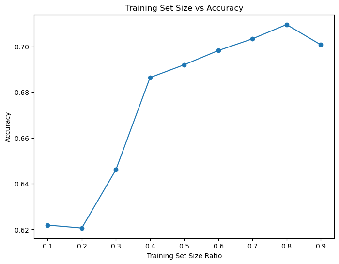

```python
# 训练集大小对测试结果的影响
train_sizes = [i/10 for i in range(1,10)]
score = []
for size in train_sizes:
    X_train_s, _, y_train_s, _ = train_test_split(X_train, y_train, train_size=size, random_state=RANDOM_SEED)
    knn = KNeighborsClassifier(n_neighbors=1, weights='distance', metric='euclidean')
    knn.fit(X_train_s, y_train_s)
    y_pred = knn.predict(X_test)
    accuracy = accuracy_score(y_test, y_pred)
    score.append(accuracy)
    print(f"Accuracy with training size {size}: {accuracy}")

plt.figure(figsize=(8, 6))
plt.plot(train_sizes, score, marker='o')
plt.title('Training Set Size vs Accuracy')
plt.xlabel('Training Set Size Ratio')
plt.ylabel('Accuracy')
plt.show()
```

# 模型调优

```python
from sklearn.neighbors import KNeighborsClassifier
from sklearn.pipeline import Pipeline
from sklearn.model_selection import GridSearchCV

# 定义多个特征提取器和分类器
# feature_extractors = [()]

classifiers = [('knn', KNeighborsClassifier()),]    # 可扩展

# 存储每次搜索的结果
search_results = []

# 对每个组合定义参数搜索空间
param_grids = []
for classifier_name, classifier in classifiers:
    parameters = {
        f'{classifier_name}__n_neighbors': [1,2,3,4,5,6,7,8,9,10],
        f'{classifier_name}__metric': ['manhattan', 'euclidean', 'chebyshev'],
        f'{classifier_name}__weights': ['uniform', 'distance'],
        }
    param_grids.append((classifier_name, parameters))
print(param_grids)
```

```
[('knn', {'knn__n_neighbors': [1, 2, 3, 4, 5, 6, 7, 8, 9, 10], 'knn__metric': ['manhattan', 'euclidean', 'chebyshev'], 'knn__weights': ['uniform', 'distance']})]
```

```python
# 创建多个 Pipeline 并进行组合，然后对每个 Pipeline 执行 GridSearch
for classifier_name, classifier in classifiers:
    pipeline = Pipeline([(classifier_name, classifier)])

    # 选择对应的参数字典
    parameters = next(param for cls_name, param in param_grids if cls_name == classifier_name)

    # 创建 GridSearchCV 对象
    grid_search = GridSearchCV(pipeline, parameters, scoring='accuracy', n_jobs=-1, verbose=3)

    # 在训练数据上搜索最佳参数
    grid_search.fit(X_val, y_val)

    # 存储每次搜索的最佳得分和参数
    search_results.append((grid_search.best_score_, classifier_name, grid_search.best_params_))

# 找出最佳得分的搜索
best_score, best_classifier, best_params = max(search_results, key=lambda x: x[0])

# 输出最佳得分的搜索结果
print("Best overall score: %0.3f" % best_score)
print("Best pipeline:", best_classifier)
print("Best parameters set:")
for param_name, param_value in best_params.items():
    print("\t%s: %r" % (param_name, param_value))
```

```
Fitting 5 folds for each of 60 candidates, totalling 300 fits
```

```
Best overall score: 0.913
Best pipeline: knn
Best parameters set:
	knn__metric: 'euclidean'
	knn__n_neighbors: 1
	knn__weights: 'uniform'
```

# 将最佳参数用于测试集

```python
from sklearn.metrics import accuracy_score, precision_score, recall_score,classification_report # 评价指标
# 使用最佳参数组合重新构建最优模型
best_classifier_obj = [cls for cls_name, cls in classifiers if cls_name == best_classifier][0]
best_pipeline = Pipeline([(best_classifier, best_classifier_obj)])

# 使用最佳参数设置重新训练模型
best_pipeline.set_params(**best_params).fit(X_train, y_train)

# 对测试集进行预测
y_pred = best_pipeline.predict(X_test)

# 性能评估
test_acc = accuracy_score(y_test, y_pred)
print(f"Accuracy: {accuracy * 100:.5f}%",end='\n\n')

print("Classification Report:")
print(classification_report(y_test, y_pred, zero_division=1))
```

```
Accuracy: 70.07503%

Classification Report:
              precision    recall  f1-score   support

           0       0.31      0.85      0.45       175
           1       0.71      1.00      0.83        94
           2       0.71      1.00      0.83        75
           3       0.96      0.91      0.94        81
           4       0.67      0.91      0.77       150
           5       0.74      0.96      0.83        78
           6       0.98      0.99      0.98        86
           7       0.79      0.99      0.88        79
           8       0.40      0.98      0.57       137
           9       0.92      0.99      0.96       132
```

[output cut: 59 more lines]

# ROC 和 AUC 浅试

```
Skipping class 54, only one class present in y_true.
Skipping class 54, only one class present in y_true.
```

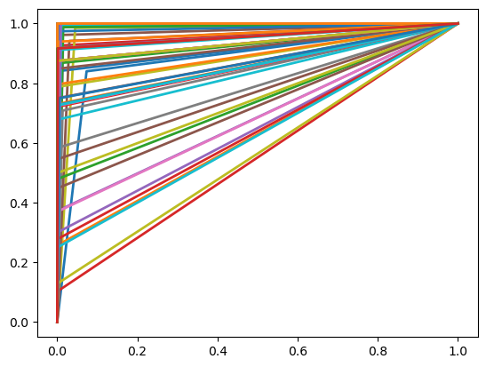

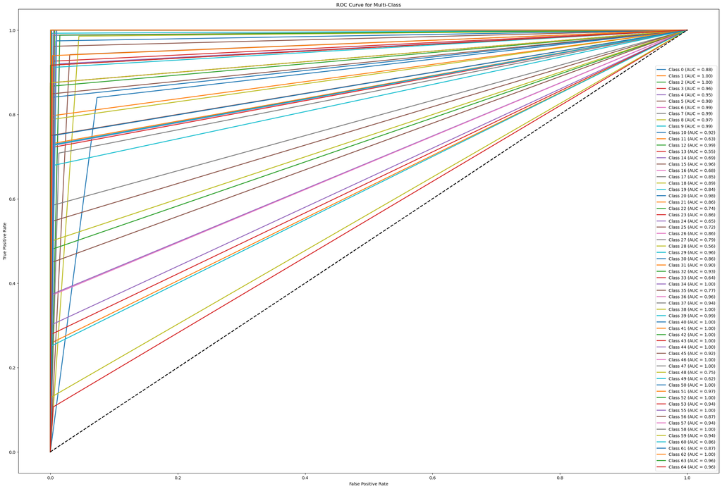

```python
from sklearn.metrics import roc_curve, roc_auc_score
from sklearn.preprocessing import label_binarize
import matplotlib.pyplot as plt
import numpy as np

y_pred_prob = knn.predict_proba(X_test)

classes = np.arange(65)  # 类别范围是从0到64

# 二值化y_test，使其适用于多类（One-vs-All）情况
y_test_binarized = label_binarize(y_test, classes=classes)

# 获取类别数，确保它与预测概率的第二维度匹配
n_classes = y_test_binarized.shape[1]

# 确保y_pred_prob的形状是(样本数, 类别数)
assert y_pred_prob.shape == (4665, n_classes), "y_pred_prob shape mismatch."

# 为每个类别计算ROC曲线和AUC分数
fpr = dict()
tpr = dict()
roc_auc = dict()

for i in range(n_classes):
    # 检查每个类别是否至少有一个正样本和一个负样本
    if len(np.unique(y_test_binarized[:, i])) > 1:
        fpr[i], tpr[i], _ = roc_curve(y_test_binarized[:, i], y_pred_prob[:, i])
        roc_auc[i] = roc_auc_score(y_test_binarized[:, i], y_pred_prob[:, i])
        plt.plot(fpr[i], tpr[i], lw=2, label='Class {0} (AUC = {1:0.2f})'.format(i, roc_auc[i]))
    else:
        # 跳过无法计算的类别
        print(f"Skipping class {i}, only one class present in y_true.")

# 绘制所有类别的ROC曲线
plt.figure(figsize=(30, 20))

# 存储成功计算ROC AUC的类别索引
calculated_classes = []

for i in range(n_classes):
    if len(np.unique(y_test_binarized[:, i])) > 1:
        fpr[i], tpr[i], _ = roc_curve(y_test_binarized[:, i], y_pred_prob[:, i])
        roc_auc[i] = roc_auc_score(y_test_binarized[:, i], y_pred_prob[:, i])
        # 将索引添加到计算列表中
        calculated_classes.append(i)
    else:
        print(f"Skipping class {i}, only one class present in y_true.")

# 现在，仅为计算过的类别绘制ROC曲线
for i in calculated_classes:
    plt.plot(fpr[i], tpr[i], lw=2, label='Class {0} (AUC = {1:0.2f})'.format(i, roc_auc[i]))
plt.plot([0, 1], [0, 1], 'k--', lw=2)
plt.xlabel('False Positive Rate')
plt.ylabel('True Positive Rate')
plt.title('ROC Curve for Multi-Class')
plt.legend(loc="best")
plt.show()
```

# 混淆矩阵

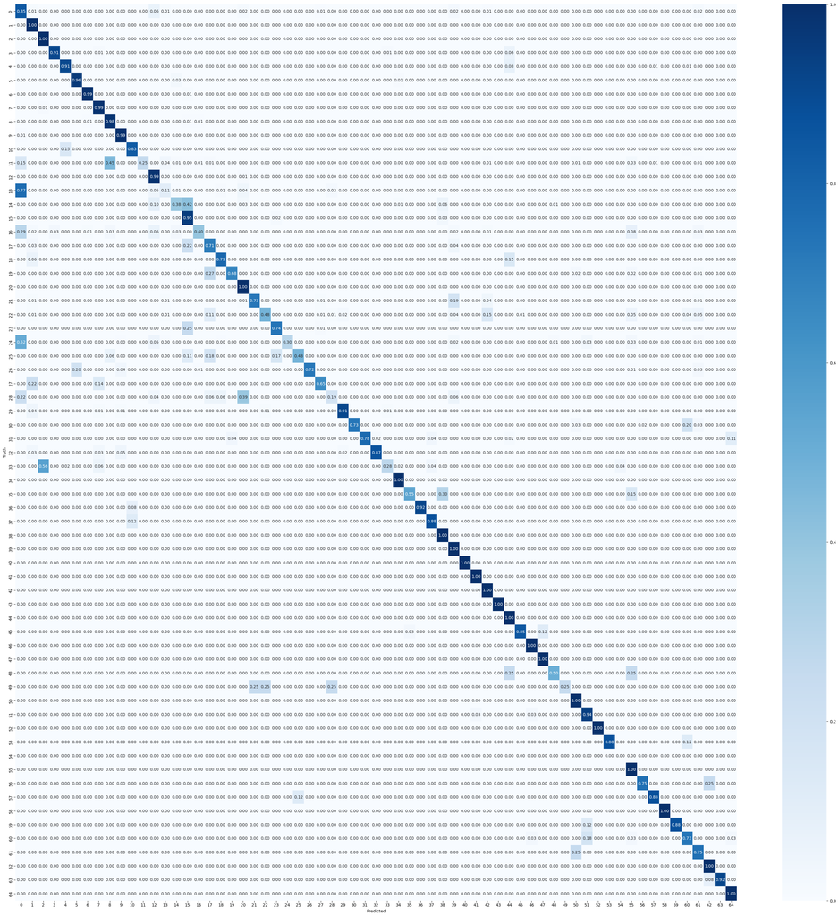

```python
# 计算混淆矩阵
cm = confusion_matrix(y_test, y_pred)

# 计算正确率
row_sums = cm.sum(axis=1)  # 计算每行的总和
cm_normalized = cm / row_sums[:, np.newaxis]

# 将 NaN 值替换为 0（如果某一行的总和为 0，则计算的结果将会是 NaN）
cm_normalized = np.nan_to_num(cm_normalized)

# 热力图可视化混淆矩阵
plt.figure(figsize=(40, 40))
sns.heatmap(cm_normalized, annot=True, fmt='.2f', cmap='Blues')  # 指定 fmt='.2f'，表示展示小数点后两位
plt.xlabel('Predicted')
plt.ylabel('Truth')
plt.show()
```